# Data Wrangling With Dplyr

Karla Villalta

3/24/2018

# Workshop data

For this workshop we will be using the flights dataset, which includes the airline on-time data for all flights that departed NYC in 2013. Also, includes useful ‘metadata’ on airlines, airports, weather, and planes. The dataset can be found by following these steps:

```r
install.packages('nycflights13')
library(nycflights13)
```

```r
# Data dimensions and format
glimpse(flights)
```

```
## Observations: 336,776
## Variables: 19
## $ year           <int> 2013, 2013, 2013, 2013, 2013, 2013, 2013, 2013,...
## $ month          <int> 1, 1, 1, 1, 1, 1, 1, 1, 1, 1, 1, 1, 1, 1, 1, 1,...
## $ day            <int> 1, 1, 1, 1, 1, 1, 1, 1, 1, 1, 1, 1, 1, 1, 1, 1,...
## $ dep_time       <int> 517, 533, 542, 544, 554, 554, 555, 557, 557, 55...
## $ sched_dep_time <int> 515, 529, 540, 545, 600, 558, 600, 600, 600, 60...
## $ dep_delay      <dbl> 2, 4, 2, -1, -6, -4, -5, -3, -3, -2, -2, -2, -2...
## $ arr_time       <int> 830, 850, 923, 1004, 812, 740, 913, 709, 838, 7...
## $ sched_arr_time <int> 819, 830, 850, 1022, 837, 728, 854, 723, 846, 7...
## $ arr_delay      <dbl> 11, 20, 33, -18, -25, 12, 19, -14, -8, 8, -2, -...
## $ carrier        <chr> "UA", "UA", "AA", "B6", "DL", "UA", "B6", "EV",...
## $ flight         <int> 1545, 1714, 1141, 725, 461, 1696, 507, 5708, 79...
## $ tailnum        <chr> "N14228", "N24211", "N619AA", "N804JB", "N668DN...
## $ origin         <chr> "EWR", "LGA", "JFK", "JFK", "LGA", "EWR", "EWR"...
## $ dest           <chr> "IAH", "IAH", "MIA", "BQN", "ATL", "ORD", "FLL"...
## $ air_time       <dbl> 227, 227, 160, 183, 116, 150, 158, 53, 140, 138...
## $ distance       <dbl> 1400, 1416, 1089, 1576, 762, 719, 1065, 229, 94...
## $ hour           <dbl> 5, 5, 5, 5, 6, 5, 6, 6, 6, 6, 6, 6, 6, 6, 6, 5,...
## $ minute         <dbl> 15, 29, 40, 45, 0, 58, 0, 0, 0, 0, 0, 0, 0, 0, ...
## $ time_hour      <dttm> 2013-01-01 05:00:00, 2013-01-01 05:00:00, 2013...
```

# Data

This is how our data looks like:

```r
# Column names
names(flights)
```

```
##  [1] "year"           "month"          "day"            "dep_time"
##  [5] "sched_dep_time" "dep_delay"      "arr_time"       "sched_arr_time"
##  [9] "arr_delay"      "carrier"        "flight"         "tailnum"
## [13] "origin"         "dest"           "air_time"       "distance"
## [17] "hour"           "minute"         "time_hour"
```

```r
head(flights)
```

```
## # A tibble: 6 x 19
##    year month   day dep_time sched_dep_time dep_delay arr_time
##   <int> <int> <int>    <int>          <int>     <dbl>    <int>
## 1  2013     1     1      517            515         2      830
## 2  2013     1     1      533            529         4      850
## 3  2013     1     1      542            540         2      923
## 4  2013     1     1      544            545        -1     1004
## 5  2013     1     1      554            600        -6      812
## 6  2013     1     1      554            558        -4      740
## # ... with 12 more variables: sched_arr_time <int>, arr_delay <dbl>,
## #   carrier <chr>, flight <int>, tailnum <chr>, origin <chr>, dest <chr>,
## #   air_time <dbl>, distance <dbl>, hour <dbl>, minute <dbl>,
## #   time_hour <dttm>
```

# Think Of Interesting Questions

Some examples are:

- Which airplanes fly the most?
- What are the top 10 most popular destinations?
- What carriers are delayed more often?
- Is there any peak hour?
- Do some days of the week have more flights than others?
- Do some carriers have more delays than others?
- Do longer flights tend to have more delays?

# Organize Your Questions

Do some questions seem to be related to each other? Try and group them, and sort them in order of fruitfulness/ease of exploration.

Examples for the flights data :

1. Which planes fly the most?
2. How do the number of flights change over time?
3. Do some carriers have more delays than others?

# dplyr

*dplyr* is a powerful R-package to transform and summarize tabular data with rows and columns. The package contains a set of functions (or “verbs”) that perform common data manipulation operations such as filtering for rows, selecting specific columns, re-ordering rows, adding new columns and summarizing data.

# dplyr vs. Base R Functions

*dplyr functions* process faster than base R functions. It is because dplyr functions were written in a computationally efficient manner. They are also more stable in the syntax and better supports data frames than vectors.

# How Do I get dplyr?

To install do:

```r
install.packages("dplyr")
```

To load do:

```r
library(dplyr)
```

# Important Verbs To Remember

| dplyr verbs | Desciption |
| --- | --- |
| select() | select columns |
| filter() | filter rows that fulfill a condition |
| arrange() | sort rows by column |
| mutate() | create new columns |
| summarise() | summarise (or aggregate) data |
| group_by() | groups the data |
| rename() | rename columns |

# Helper Functions

| Helper | Desciption |
| --- | --- |
| starts_with() | Starts with a prefix |
| ends_with() | Select columns that end with a character string |
| contains() | Select columns that contain a character string |
| matches() | Select columns that match a regular expression |
| num_range() | Numerical range like x01, x02 |
| one_of() | Variables in character vector |
| everything() | All variables |

# Pipe Operator %>%

*dplyr* utilizes pipe operator from another package (magrittr). All the functions in dplyr package can be used without the pipe operator but the pipe lets to wrap multiple functions together. For example: You can mutate a column and select a subset of columns in a single dplyr pipeline.

Example:

```r
sample_n(select(flights, year, month, carrier, air_time),10)
```

Or

```r
flights %>% select(year, month, carrier, air_time) %>% sample_n(10)
```

# Selecting Rows

This is something that may come handy when you are exploring your data or when dealing with a large dataset.

Selecting Random N Rows:

```r
sample_n(flights, 10)
```

Selecting Random Fraction of Rows:

```r
# Randomly selects 20% of the data
sample_frac(flights, 0.20)
```

# Selecting or Dropping variables

You can select the cloumns that you need for your computations by using *select()*. Columns can be dropped by adding *-* before the column name:

```r
flights %>%
  mutate(total_delay = dep_delay + arr_delay) %>%
  select(-dep_delay, -arr_delay, -time_hour) %>%
  head()
```

# Which planes fly the most?

Tailnum uniquely identifies a plane.

# Answer:

```r
flights %>%
  group_by(tailnum) %>%
  summarize(num_flights = n(),
            total_air_time = sum(air_time, na.rm = TRUE),
            max_distance = max(distance)) %>%
  arrange(-num_flights, -total_air_time) %>%
  head()
```

```
## # A tibble: 6 x 4
##   tailnum num_flights total_air_time max_distance
##     <chr>       <int>          <dbl>        <dbl>
## 1    <NA>        2512              0         4963
## 2  N725MQ         575          48921         1147
## 3  N722MQ         513          42664         1147
## 4  N723MQ         507          41496         1147
## 5  N711MQ         486          40709         1147
## 6  N713MQ         483          40031         1147
```

# How do the number of flights change over time?

You can utilize multiple functions to modify and aggregate variables.

# Answer:

```r
flights %>%
  mutate(date = paste(year, month, day, sep='-'),
         date = as.Date(date)) %>%
  group_by(date) %>%
  summarise(count = n())
```

```
## # A tibble: 365 x 2
##          date count
##        <date> <int>
##  1 2013-01-01   842
##  2 2013-01-02   943
##  3 2013-01-03   914
##  4 2013-01-04   915
##  5 2013-01-05   720
##  6 2013-01-06   832
##  7 2013-01-07   933
##  8 2013-01-08   899
##  9 2013-01-09   902
## 10 2013-01-10   932
## # ... with 355 more rows
```

# How do the number of flights change over time?

You should use *group_by* to answer this question.

# Answer:

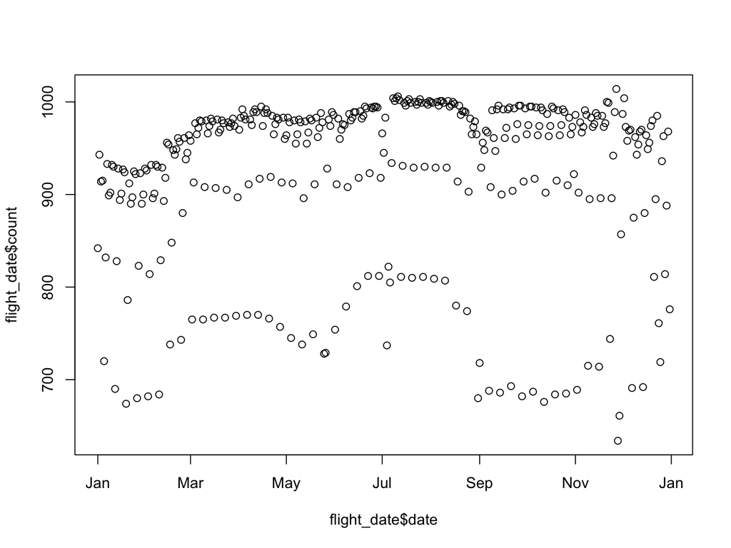

```r
flight_date <- flights %>%
  mutate(date = paste(year, month, day, sep='-'),
         date = as.Date(date)) %>%
  group_by(date) %>%
  summarise(count = n())

plot(flight_date$date, flight_date$count)
```

# How do the number of flights change over time?

Regular R functions can piped as well. For example:

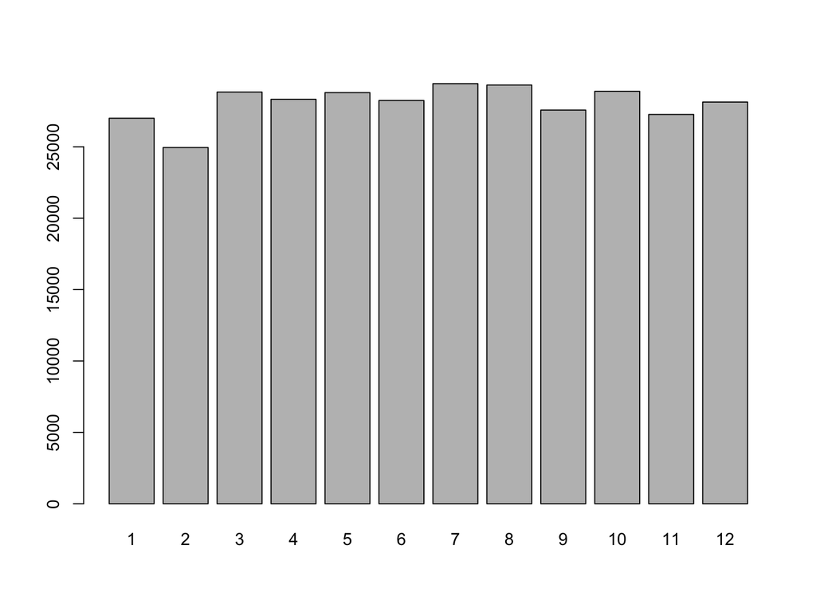

```r
select(flights, month) %>%
  table() %>%
  barplot()
```

```r
select(flights, month) %>%
  table()
```

```
## .
##     1     2     3     4     5     6     7     8     9    10    11    12
## 27004 24951 28834 28330 28796 28243 29425 29327 27574 28889 27268 28135
```

# Do some carriers have more delays than others?

Your turn!!

# Answer:

```r
flights %>%
  select(carrier, arr_delay) %>%
  group_by(carrier) %>%
  summarize(num_flights = n(),
            total_arr_delay = sum(arr_delay, na.rm = TRUE),
            delay_per_flight = total_arr_delay/num_flights) %>%
  arrange(-delay_per_flight) %>%
  head(n = 7)
```

```
## # A tibble: 7 x 4
##   carrier num_flights total_arr_delay delay_per_flight
##     <chr>       <int>           <dbl>            <dbl>
## 1      F9         685           14928        21.792701
## 2      FL        3260           63868        19.591411
## 3      EV       54173          807324        14.902701
## 4      YV         601            8463        14.081531
## 5      OO          32             346        10.812500
## 6      MQ       26397          269767        10.219608
## 7      WN       12275          116214         9.467536
```

# Does destination contribute to arrival delay?

```r
flights %>%
  select(dest, arr_delay) %>%
  group_by(dest) %>%
    summarize(num_flights = n(),
            total_arr_delay = sum(arr_delay, na.rm = TRUE),
            delay_per_flight = total_arr_delay / num_flights) %>%
  filter(num_flights > 25) %>%
  arrange(delay_per_flight) %>%
  top_n(5, delay_per_flight)
```

```
## # A tibble: 5 x 4
##    dest num_flights total_arr_delay delay_per_flight
##   <chr>       <int>           <dbl>            <dbl>
## 1   MSN         572           11229         19.63112
## 2   TYS         631           13912         22.04754
## 3   OKC         346            9645         27.87572
## 4   TUL         315            9896         31.41587
## 5   CAE         116            4427         38.16379
```

# Does destination contribute to arrival delay?

Order table by *arr_delay*, and visualize differences between destinations.

[figure not shown]

# Resources

Dplyr cheat sheet can be found [here](https://www.rstudio.com/wp-content/uploads/2015/02/data-wrangling-cheatsheet.pdf)

## Tutorials

- General use of dplyr [here](http://genomicsclass.github.io/book/pages/dplyr_tutorial.html) and [here](https://www.listendata.com/2016/08/dplyr-tutorial.html)
- Non-standard-evaluation [here](http://rmhogervorst.nl/cleancode/blog/2016/06/13/NSE_standard_evaluation_dplyr.html)